# Capstone Project Tasks

Luis Talavera

2022-09-11

## Summary

This file will document the progress on the final project to build a predictive text model of the Johns Hopkins University data science specialization.

## Task 0: Understanding the problem

Tasks to accomplish

Obtaining the data - Can you download the [data](https://d396qusza40orc.cloudfront.net/dsscapstone/dataset/Coursera-SwiftKey.zip) and load/manipulate it in R?

Familiarizing yourself with NLP and text mining - Learn about the basics of natural language processing and how it relates to the data science process you have learned in the Data Science Specialization.

Questions to consider

1. What do the data look like?
2. Where do the data come from?
3. Can you think of any other data sources that might help you in this project?
4. What are the common steps in natural language processing?
5. What are some common issues in the analysis of text data?
6. What is the relationship between NLP and the concepts you have learned in the Specialization?

## Task 1: Getting and cleaning data

Tasks to accomplish

Tokenization - identifying appropriate tokens such as words, punctuation, and numbers. Writing a function that takes a file as input and returns a tokenized version of it.

Profanity filtering - removing profanity and other words you do not want to predict.

```r
zip_url <- "https://d396qusza40orc.cloudfront.net/dsscapstone/dataset/Coursera-SwiftKey.zip"
zip_file <- "Coursera-Swiftkey.zip"
data_dir <- "./data/final"

if(!file.exists(paste0("./data/", zip_file))) {
  download(zip_url)
}

if(!file.exists(data_dir)) {
  setwd("./data")
  unzip(zip_file)
  setwd("../")
}
```

```r
sample_text <- function(file_name, output_name) {
  set.seed(1234)

  lines <- scan(file_name, character(0), sep = "\n") # separate each line
  n_lines <- as.numeric(countLines(file_name))

  #conn <- file(file_name, "r")
  #lines <- readLines(conn, encoding="UTF-8")

  # Fix wrong file encoding
  fixed <- iconv(lines, from = "UTF-8", to = "Windows-1252")
  Encoding(fixed) <- "UTF-8"

  selected_lines <- sample(n_lines, size = n_lines/1000, replace = FALSE)
  subset_text <- fixed[selected_lines]

  writeLines(subset_text, con=output_name, "\n")
  #close(conn)
}

if(!file.exists(paste0(data_dir, "/en_US/en_US_sample.twitter.txt"))) {
  sample_text(paste0(data_dir, "/en_US/en_US.twitter.txt"),
              paste0(data_dir, "/en_US/en_US_sample.twitter.txt"))

}
```

```r
# Create a list to store all data transformations
data <- list()
```

```r
conn <- file(paste0(data_dir, "/en_US/en_US_sample.twitter.txt"), "r")
lines <- readLines(conn,encoding="UTF-8")
fixed <- iconv(lines, from = "UTF-8", to = "Windows-1252")
Encoding(fixed) <- "UTF-8"
close(conn)

data$text_tibble <- tibble(line = 1:length(lines), text = lines)
data$original <- data$text_tibble %>%
                 unnest_tokens(token, text, strip_punct = TRUE) %>%
                 filter(!is.na(token)) %>%
                 mutate(word = token)

# Remove stopwords
data$wo_stepwords <- data$original %>%
                     anti_join(stop_words, by=c("token"="word"))
```

```r
# Using sentimentr
data$sentences <- get_sentences(lines)

profanity_terms <- extract_profanity_terms(data$sentences) # names: neutral, profanity, sentence

profane_words <- unique(unlist(profanity_terms$profanity))

# Filter profanity
data$wo_profanity <- data$wo_stepwords %>%
                     filter(!token %in% profane_words)
```

```r
# Remove numbers
data$wo_numbers <- data$wo_profanity %>% filter(!grepl("^\\d+$", word))

# Remove misspelled words
data$correct_words <- data$wo_numbers %>% filter(hunspell_check(word))
```

## Exploratory Analysis

### 1-gram

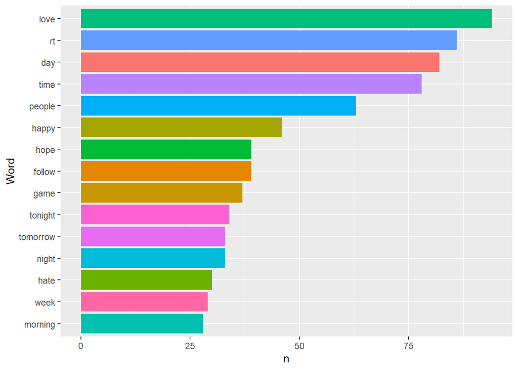

```r
wf <- count(data$correct_words, word, sort = TRUE)
wf10 <- head(wf,15)

ggplot(wf10, aes(x=reorder(word, n), y=n, fill = word)) +
  geom_bar(stat='identity', show.legend = FALSE) +
  coord_flip() +
  xlab("Word")
```

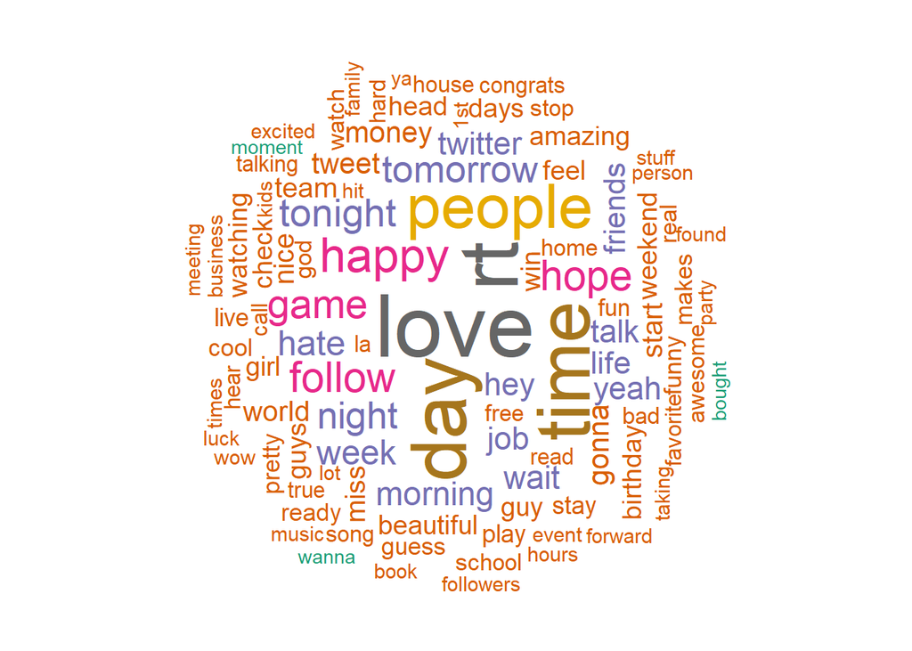

```r
set.seed(1234)
wordcloud(words = wf$word, freq = wf$n, min.freq = 10,
          max.words=100, random.order=FALSE, rot.per=0.35,
          colors=brewer.pal(8, "Dark2"))
```

```r
data$bing_word_counts <- data$wo_profanity %>%
  inner_join(get_sentiments("bing")) %>%
  count(word, sentiment, sort = TRUE) %>%
  ungroup()
```

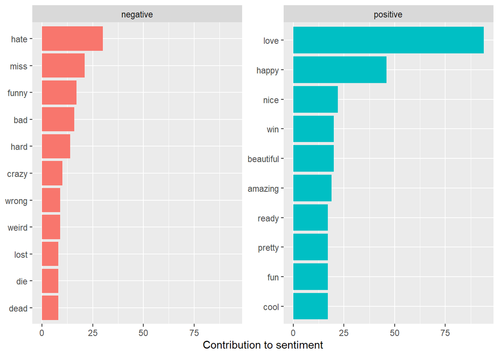

```r
data$bing_word_counts %>%
  group_by(sentiment) %>%
  slice_max(n, n = 10) %>%
  ungroup() %>%
  mutate(word = reorder(word, n)) %>%
  ggplot(aes(n, word, fill = sentiment)) +
  geom_col(show.legend = FALSE) +
  facet_wrap(~sentiment, scales = "free_y") +
  labs(x = "Contribution to sentiment",
       y = NULL)
```

```r
data$nrc_word_counts <- data$wo_profanity %>%
  inner_join(get_sentiments("nrc")) %>%
  count(word, sentiment, sort = TRUE) %>%
  ungroup()
```

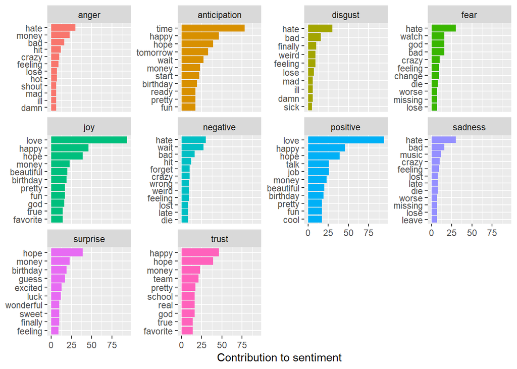

```r
data$nrc_word_counts %>%
  group_by(sentiment) %>%
  slice_max(n, n = 10) %>%
  ungroup() %>%
  mutate(word = reorder(word, n)) %>%
  ggplot(aes(n, word, fill = sentiment)) +
  geom_col(show.legend = FALSE) +
  facet_wrap(~sentiment, scales = "free_y") +
  labs(x = "Contribution to sentiment",
       y = NULL)
```

### 2-gram

```r
data$bigram <- data$text_tibble %>%
                 unnest_tokens(bigram, text, token = "ngrams", n = 2) %>%
                 # Replace na tokens with blank str
                 # mutate(word = if_else(is.na(bigram), "", bigram))
                 filter(!is.na(bigram))
```

```r
bigrams_separated <- data$bigram %>%
  separate(bigram, c("word1", "word2"), sep = " ")

bigrams_filtered <- bigrams_separated %>%
  filter(!word1 %in% stop_words$word) %>%
  filter(!word2 %in% stop_words$word) %>%
  filter(!word1 %in% profane_words) %>%
  filter(!word2 %in% profane_words) %>%
  filter(!is.na(word1)) %>%
  filter(!is.na(word2)) %>%
  filter(!grepl("^\\d+$", word1)) %>%
  filter(!grepl("^\\d+$", word2)) %>%
  filter(hunspell_check(word1)) %>%
  filter(hunspell_check(word2))

data$bigrams_separated <- bigrams_filtered
data$bigrams_filtered <- bigrams_filtered %>%
                         unite(bigram, word1, word2, sep = " ")
```

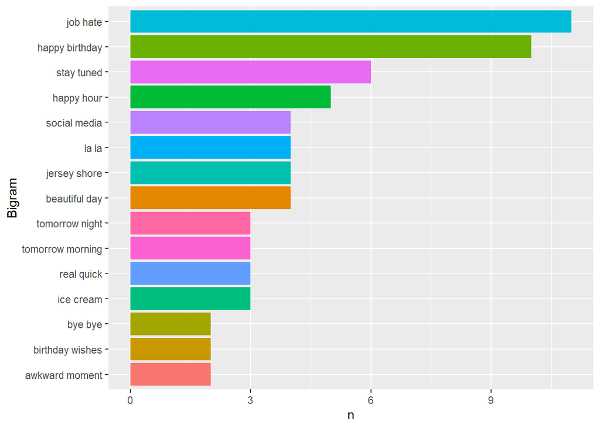

```r
bf <- count(data$bigrams_filtered, bigram, sort = TRUE)
bf10 <- head(bf,15)

ggplot(bf10, aes(x=reorder(bigram, n), y=n, fill = bigram)) +
  geom_bar(stat='identity', show.legend = FALSE) +
  coord_flip() +
  xlab("Bigram")
```

### 3-gram

```r
data$trigram <- data$text_tibble %>%
                 unnest_tokens(trigram, text, token = "ngrams", n = 3) %>%
                 # Replace na tokens with blank str
                 mutate(word = if_else(is.na(trigram), "", trigram))
```

```r
trigrams_separated <- data$trigram %>%
  separate(trigram, c("word1", "word2", "word3"), sep = " ")

trigrams_filtered <- trigrams_separated %>%
  filter(!word1 %in% stop_words$word) %>%
  filter(!word2 %in% stop_words$word) %>%
  filter(!word3 %in% stop_words$word) %>%
  filter(!word1 %in% profane_words) %>%
  filter(!word2 %in% profane_words) %>%
  filter(!word3 %in% profane_words) %>%
  filter(!is.na(word1)) %>%
  filter(!is.na(word2)) %>%
  filter(!is.na(word3)) %>%
  filter(!grepl("^\\d+$", word1)) %>%
  filter(!grepl("^\\d+$", word2)) %>%
  filter(!grepl("^\\d+$", word3)) %>%
  filter(hunspell_check(word1)) %>%
  filter(hunspell_check(word2)) %>%
  filter(hunspell_check(word3))

data$trigrams_separated <- trigrams_filtered
data$trigrams_filtered <- trigrams_filtered %>%
                         unite(trigram, word1, word2, word3, sep = " ")
```

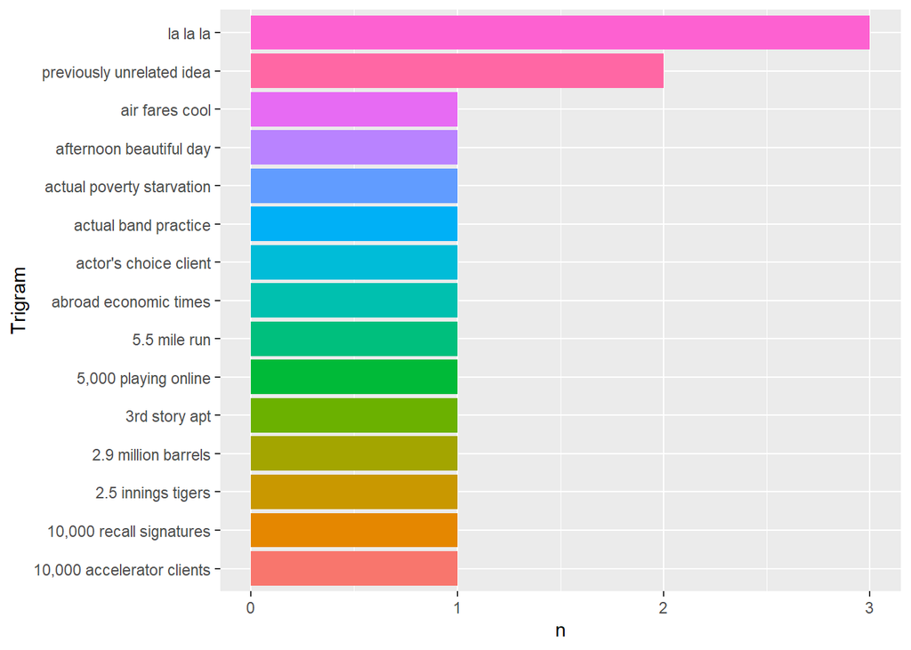

```r
tf <- count(data$trigrams_filtered, trigram, sort = TRUE)
tf10 <- head(tf,15)

ggplot(tf10, aes(x=reorder(trigram, n), y=n, fill = trigram)) +
  geom_bar(stat='identity', show.legend = FALSE) +
  coord_flip() +
  xlab("Trigram")
```

### TODO

Ir explicando los pasos y describir mis descubrimientos